# Analysis: Propensity Score Matching & Interval Regression

Off the boat and into the bank: Direct market channels and seafood sales

# 1 Introduction

This analysis asks which direct marketing strategies, such as selling solely Direct To Consumer (DTC) channels versus multi-channel portfolios that include direct sales to retailers, foodservices, institutions, or source-identified distributors, maximize seafood sales income for U.S. DSM? We address this gap using data from the 2023 American Seafood Harvesters Marketing Practices Survey (ASHMPS), the first nationally representative dataset of U.S. direct marketing fishers (Advani et al., 2024). We draw upon a causal inference framework, using propensity score matching and interval regression, to estimate the effects of various marketing strategies on revenue from direct seafood sales, while controlling for regional contexts.

## 1.1 Overview

Before diving into our methodological approach which uses a smaller, experimentally-comparable sample size, let’s get a sense of how direct marketing strategies have been engaged with in our larger survey sample.

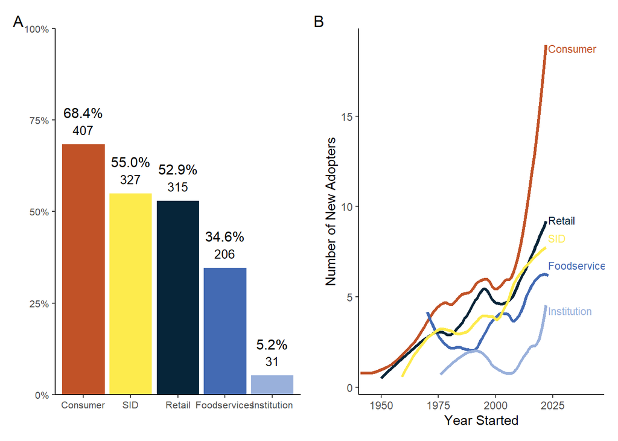

Figure 1: Findings from the ASHMPS (N=595) indicating (A) percent engagement with (and total N for) each marketing channel, and (B) the history of adoption of various marketing channels. (percentages are more than a 100% because multiple channels could have been engaged with, engagement history has been loess smoothed).

```r
mkt_channels <- ashmps_data %>%
  select(ExternalReference, Q0.2a:Q0.2e) %>%
  rename(Consumer = 'Q0.2a',
         Retail = 'Q0.2b',
         Foodservices = 'Q0.2c',
         Institution = 'Q0.2d',
         SID = 'Q0.2e') %>%
  pivot_longer(Consumer:SID, names_to = "channel") %>%
  filter(value == "Yes") %>%
  group_by(channel) %>%
  summarise(count = n_distinct(ExternalReference[channel == channel]),
            .groups = "drop") %>%
  mutate(total = n_distinct(ashmps_data$ExternalReference),
         pct = count / total,
         pct_label = percent(pct, accuracy = 0.1))

f1_a <- ggplot(mkt_channels, aes(x = reorder(channel, -pct), y = pct, fill = channel)) +
  geom_bar(stat = "identity") +
  geom_text(aes(label = pct_label), vjust = -2.5, size = 4) +
  geom_text(aes(label = count), vjust = -1, size = 3.5) +
  #scale_fill_viridis(discrete = TRUE, direction = -1) +
  scale_fill_manual(breaks = c("Consumer", "Retail", "Foodservices", "Institution", "SID"),
                    values = c("#C15227", "#062539", "#436AB3", "#99B0DB", "#FDEB4D")) +
  scale_y_continuous(limits = c(0, 1), labels = percent_format(), expand = c(0, 0)) +
  labs(x = NULL, y = NULL) +
  theme_classic() +
  theme(
    legend.position = "none",
    panel.grid = element_blank(),
    axis.text = element_text(size = 8)
  )


# Marketing Experience History
mkt_exp <- ashmps_data %>%
  select(ExternalReference, Q1.2_1, Q2.2_1, Q3.2_1, Q4.2_1, Q5.3_1) %>%
  rename("Consumer" = Q1.2_1,
         "Retail" = Q2.2_1,
         "Foodservices" = Q3.2_1,
         "Institution" = Q4.2_1,
         "SID" = Q5.3_1) %>%
  mutate(earliest_dsm = pmin(Consumer, Retail, Foodservices, Institution, SID, na.rm = TRUE),
         mkt_exp = 2023 - earliest_dsm)

xp_long <- mkt_exp %>%
  pivot_longer(cols = c(Consumer:SID), names_to = "channel", values_to = "start_year") %>%
  filter(!is.na(start_year)) %>%
  mutate(experience = 2023 - start_year)

adoption <- xp_long %>% count(channel, start_year)

labels_df <- tibble(channel = c("SID", "Consumer", "Retail", "Foodservices", "Institution"),
                    start_year = 2023,
                    y_pos = c(8.25, 18.75, 9.25, 6.75, 4.25))

f1_b <- ggplot(adoption, aes(x = start_year, y = n, color = channel)) +
   geom_smooth(method = "loess", se = FALSE, size = 1.2, span= 0.5, alpha = 0.7) +
   scale_color_manual(breaks = c("SID", "Consumer", "Retail", "Foodservices", "Institution"),
                   values = c("#FDEB4D", "#C15227", "#062539", "#436AB3", "#99B0DB")) +
  geom_text(data = labels_df,
            aes(x = start_year, y = y_pos, label = channel, color = channel),
            hjust = 0, size = 3) +
  scale_x_continuous(expand = expansion(mult = c(0.01, 0.3))) +
   labs(#subtitle = "Adoption of Direct Marketing Channels Over Time",
        x = "Year Started",
        y = "Number of New Adopters",
        color = "Channel") +
   theme_classic() +
  theme(legend.position = "none")


fig_1 <- f1_a + f1_b + plot_annotation(tag_levels = 'A')

fig_1
```

```r
ggsave(plot = fig_1, here("plots", "Fig1.tif"), width = 183, height = 80, units = "mm", bg = "white")

table_2 <- ashmps_data %>%
  select(ExternalReference, Q0.2a:Q0.2e) %>%
  rename(Consumer = 'Q0.2a',
         Retail = 'Q0.2b',
         Foodservices = 'Q0.2c',
         Institution = 'Q0.2d',
         SID = 'Q0.2e') %>%
  mutate(Consumer = Consumer == "Yes",
    RetailFood = (Retail == "Yes" | Foodservices == "Yes"),
    SIDInst = (SID == "Yes" | Institution == "Yes")) %>%
  summarise(Consumer = sum(Consumer, na.rm = TRUE),
    RetailFood = sum(RetailFood, na.rm = TRUE),
    SIDInst = sum(SIDInst, na.rm = TRUE),
    total = n()) %>%
  tidyr::pivot_longer(-total, names_to = "channel", values_to = "count") %>%
  mutate(pct = count / total,
    pct_label = percent(pct, accuracy = 0.1))

table_2_subset <- ashmps_data %>%
  select(ExternalReference, Q0.2a, Q1.1a:Q1.1f) %>%
  filter(Q0.2a == "Yes") %>%
  rename(OffBoat = 'Q1.1a',
         HomeDelivery = 'Q1.1c',
         Roadside = 'Q1.1b',
         FarmersMarket = 'Q1.1d',
         CSF = 'Q1.1e',
         OtherDSM = 'Q1.1f') %>%
  pivot_longer(OffBoat:OtherDSM, names_to = "channel") %>%
  filter(value == "Yes") %>%
  group_by(channel) %>%
  summarise(count = n_distinct(ExternalReference), .groups = "drop") %>%
  mutate(total = n_distinct(ashmps_data$ExternalReference[ashmps_data$Q0.2a == "Yes"]),
         pct = count / total,
         pct_label = percent(pct, accuracy = 0.1))


table_2
```

```
# A tibble: 3 × 5
  total channel    count   pct pct_label
  <int> <chr>      <int> <dbl> <chr>
1   595 Consumer     407 0.684 68.4%
2   595 RetailFood   365 0.613 61.3%
3   595 SIDInst      337 0.566 56.6%
```

```r
table_2_subset
```

```
# A tibble: 6 × 5
  channel       count total    pct pct_label
  <chr>         <int> <int>  <dbl> <chr>
1 CSF              30   407 0.0737 7.4%
2 FarmersMarket    55   407 0.135  13.5%
3 HomeDelivery    133   407 0.327  32.7%
4 OffBoat         321   407 0.789  78.9%
5 OtherDSM         57   407 0.140  14.0%
6 Roadside        111   407 0.273  27.3%
```

# 2 Methods

## 2.1 Data Source and Variable Description

We use data from the ASHMPS, which had a total of 595 valid responses. However, our sample for analysis is restricted to 323 respondents who reported complete data on marketing strategies, direct sales revenue, and other covariates of interest. The primary research question is whether and how engagement with direct marketing channels – particularly combinations that include or exclude DTC sales – affects revenue levels.

### 2.1.1 Dependent Variable

Our dependent variable is thus reported income from direct seafood sales, which is reported in ordered income ranges (e.g. $1 - $999, $1,000 - $9,999, etc.) Due to low or no reported direct seafood sales income above $250,000 in certain regions of the US, the last income bracket is collapsed to “$250,000 and over”. This is comparable with USDA classifications of farms selling locally and directly. Low and Vogel (2011) classify small farms as those with less than ‘$50,000’ in gross annual sales, medium-sized farms as those with sales between $50,000 and $250,000, and large farms with gross annual sales exceeding $250,000. While surveys like the LFMPS ask for actual dollar amounts of agricultural direct sales value, the ASHMPS is limited to asking only for income ranges of direct seafood sales. For this reason, we conduct interval regressions rather than regressions using reported dollar values of direct sales.

### 2.1.2 Independent Variables

We created two independent variables to model marketing strategy. The first, DTC, is a binary variable indicating whether the business engages (1) or does not (0) engage in direct sales to consumers. The second independent variable, Marketing Strategy, is a categorical variable capturing the different combinations of market channel engagement (e.g. DTC only, DTC and Direct to Retail, SID only, etc.). Rare combinations were grouped into an “Other” category based on frequency and distribution of strategies across regions.

### 2.1.3 Additional Covariates

We determine a list of variables that may influence whether operations choose a particular marketing channel or not. We want to capture as many factors as we can, while trying to achieve balance between control and treatment groups. This way we can make the case that there are few unobserved factors which may influence which market strategies get adopted. To avoid multicollinearity, variables that represented similar aspects of business or the marketing environment and were highly correlated with other covariates were not included. These include volumes of seafood landed, the value (USD$) of seafood sales, number of operations selling directly to retail, the value of direct agricultural sales to wholesale, etc.

[output not shown]

```r
pre_olr_data <- ashmps_data %>%
  select(ExternalReference, Q6.1, Q6.3, NOAA_region, Q0.2a:Q0.2e, Q1.2_1, Q2.2_1, Q3.2_1, Q4.2_1, Q5.3_1, Q7.1, Q7.2a_1, Q6.4_Direct_a:Q6.4_Direct_c, Q6.4_Direct_g:Q6.4_Direct_i, Q7.2b_1, Q7.2e_1, Q7.2d_1, Q7.2f_1, Q6.9_Male_Full.time, Q6.9_Male_Part.time, Q6.9_Female_Full.time, Q6.9_Female_Part.time) %>%
  # Income Brackets
  rename(direct_income = 'Q6.1',
       gross_income = 'Q6.3') %>%
  drop_na(direct_income, gross_income) %>%
  mutate(direct_income = factor(direct_income, ordered = TRUE,
                       levels = c("$1 - 999", "$1,000 - 2,499", "$2,500 - 4,999",
                                  "$5,000 - 9,999", "$10,000 - 24,999",
                                  "$25,000 - 49,999", "$50,000 - 99,999",
                                  "$100,000 - 249,999", "$250,000 - 499,999",
                                  "$500,000 - 999,999", "$1,000,000 - 2,499,999",
                                  "$2,500,000 - 4,999,999",
                                  "$5,000,000 and over"))) %>%
  mutate(direct_income_clip = fct_collapse(direct_income,
                                     "$250,000 and over" = c("$250,000 - 499,999", "$500,000 - 999,999", "$1,000,000 - 2,499,999", "$2,500,000 - 4,999,999", "$5,000,000 and over"))) %>%
  mutate(gross_income = factor(gross_income,
                ordered = TRUE,
                levels = c("$1 - 999", "$1,000 - 9,999",
                           "$10,000 - 49,999", "$50,000 - 99,999",
                           "$100,000 - 499,999", "$500,000 - 999,999",
                           "$1,000,000 - 4,999,999", "$5,000,000 and over"))) %>%
  mutate(income_lower = case_when(
    direct_income_clip == "$1 - 999" ~ 1,
    direct_income_clip == "$1,000 - 2,499" ~ 1000,
    direct_income_clip == "$2,500 - 4,999" ~ 2500,
    direct_income_clip == "$5,000 - 9,999" ~ 5000,
    direct_income_clip == "$10,000 - 24,999" ~ 10000,
    direct_income_clip == "$25,000 - 49,999" ~ 25000,
    direct_income_clip == "$50,000 - 99,999" ~ 50000,
    direct_income_clip == "$100,000 - 249,999" ~ 100000,
    direct_income_clip == "$250,000 and over" ~ 250000),
    income_upper = case_when(
    direct_income_clip == "$1 - 999" ~ 999,
    direct_income_clip == "$1,000 - 2,499" ~ 2499,
    direct_income_clip == "$2,500 - 4,999" ~ 4999,
    direct_income_clip == "$5,000 - 9,999" ~ 9999,
    direct_income_clip == "$10,000 - 24,999" ~ 24999,
    direct_income_clip == "$25,000 - 49,999" ~ 49999,
    direct_income_clip == "$50,000 - 99,999" ~ 99999,
    direct_income_clip == "$100,000 - 249,999" ~ 249999,
    direct_income_clip == "$250,000 and over" ~ Inf)) %>%
  # Marketing Channels
  rename(Consumer = 'Q0.2a',
         Retail = 'Q0.2b',
         Foodservice = 'Q0.2c',
         Institution = 'Q0.2d',
         SID = 'Q0.2e') %>%
  mutate(across(Consumer:SID, ~ ifelse(.x == "Yes", 1, 0))) %>%
  rowwise() %>% mutate(
    num_channels = sum(c_across(c(Consumer, Retail, Foodservice, Institution, SID))),
    channel_binary = if_else(num_channels == 1, 0, 1)
  ) %>% ungroup() %>%
  mutate(strategy_type = pmap_chr(across(c(Consumer, Retail, Foodservice, Institution, SID)), ~ {
    active_channels <- c("C", "R", "F", "I", "D")[c(...) == 1]
    if(length(active_channels) == 0) "None" else paste(active_channels, collapse = "+")
  })) %>%
    # Region
  mutate(NOAA_region = fct_recode(NOAA_region,
                                  Alaska = "North Pacific (Alaska)",
                                  'West Coast' = "Pacific",
                                  Hawaii = "Western Pacific (Hawaii)"),
         NOAA_region = fct_relevel(NOAA_region, "Mid-Atlantic")) %>%
  # Predictor Variables
  rename(Live = "Q6.4_Direct_a",
         Fresh_chilled = "Q6.4_Direct_b",
         Frozen = "Q6.4_Direct_c",
         Finfish = "Q6.4_Direct_g",
         Crustaceans = "Q6.4_Direct_h",
         Mollusks = "Q6.4_Direct_i",
         Family_owned = "Q7.1",
         Sex = Q7.2a_1,
         Age = Q7.2b_1,
         MajorOccupation = Q7.2e_1,
         Race = Q7.2d_1) %>%
  mutate(across(Live:Mollusks, ~ ifelse(.x == "Yes", 1, 0))) %>%
  mutate(across(Family_owned, ~as.numeric(. == "Yes"))) %>%
  mutate(across(Sex, ~as.numeric(. == "Male"))) %>%
      mutate(MajorOccupation = fct_recode(MajorOccupation,
                                  "Seafood-related" = "Fishing or seafood sales",
                                  Other = "Work other than fishing or seafood sales"),
         MajorOccupation = fct_relevel(MajorOccupation, "Seafood-related")) %>%
  mutate_if(is.character, as.factor) %>%
  mutate(Experience = 2023-Q7.2f_1) %>%
  # Collapsing Race
  mutate(is_multiracial = str_detect(Race, ","),
    OMB_Race = case_when(
      is_multiracial ~ "Multiracial",
      Race %in% c("White") ~ "White",
      Race %in% c("Japanese","Vietnamese","Other Asian", "Chinese", "Filipino", "Korean") ~ "Asian",
      Race %in% c("Native Hawaiian", "Other Pacific Islander or Chamorro or Samoan") ~ "Native Hawaiian or Other Pacific Islander",
      Race %in% c("Black or African American") ~ "Black or African American",
      Race %in% c("American Indian or Alaska Native") ~ "American Indian or Alaska Native",
      TRUE ~ "NA")) %>%
  mutate(OMB_Race = as.factor(OMB_Race)) %>%
  #Number employees
  mutate_at(c('Q6.9_Male_Full.time', 'Q6.9_Male_Part.time', 'Q6.9_Female_Full.time', 'Q6.9_Female_Part.time'), as.numeric) %>%
  filter(Q6.9_Male_Full.time != 13000) %>%
  mutate(num_employees = select(., Q6.9_Male_Full.time:Q6.9_Female_Part.time) %>% rowSums(na.rm = TRUE) %>% log1p()) %>%
  # Market Experience
  mutate(earliest_dsm =pmin(Q1.2_1, Q2.2_1, Q3.2_1, Q4.2_1, Q5.3_1, na.rm = TRUE),
         mkt_exp = 2023 - earliest_dsm) %>%
  # External Predictors
  left_join(external_data, by = "ExternalReference") %>%
  mutate(medincome = as.numeric(medincome),
          RUCC_2023 = factor(RUCC_2023, ordered = TRUE, #orderd Rural-to-Urbanized
         levels = c("9","8","7","6","5","4","3","2","1"))) %>%
  select(!c(Q6.9_Male_Full.time:Q6.9_Female_Part.time, zipcode, county, state, state_code, FIPS, Description, medinc_moe, Q7.2f_1, Race, is_multiracial, earliest_dsm, Q1.2_1, Q2.2_1, Q3.2_1, Q4.2_1, Q5.3_1)) %>%
  drop_na()

#Calculate counts
strategy_count <- pre_olr_data %>% filter(NOAA_region != "Hawaii") %>% count(strategy_type, name = "Count")

#create vector of strategy types to keep
strategies_to_keep <- strategy_count %>%
  filter(Count >= 20) %>%
  pull(strategy_type)

olr_data <- pre_olr_data %>%
  mutate(strategy_type_grouped = if_else(
    strategy_type %in% strategies_to_keep, strategy_type, "Other")
  ) %>%
  mutate(strategy_type_grouped = fct_relevel(strategy_type_grouped, "C"))
```

## 2.2 Propensity Score Matching

Propensity score score matching is a technique that develops control and treatment groups with similar characteristics that, in this context, reduce bias from non-random assignment into marketing channels. We run a logit regression where the covariates listed above are run in a regression to predect whether a fisher engages with DTC sales. The fitted values from this regression are used to calculate a ‘propensity score’ for each observation.

We then employ nearest neighbor matching with replacement (Ho et al., 2011) to construct a control group of non-DTC businesses whose observed characteristics closely resemble those of DTC businesses. To help control for regional differences in direct seafood sales, the matches were restricted to each region businesses operated in.

### 2.2.1 Common Support

```r
nnr_1 <- matchit(Consumer ~ Sex + mkt_exp + MajorOccupation + OMB_Race + Family_owned + Live + Fresh_chilled + Frozen + Finfish + Crustaceans + Mollusks + num_employees + NOAA_region + medincome + RUCC_2023  + seafood_jobs + landing_dollars + ag_retail_usd + ag_wholesale_ops + fsa_usd,
                 data = olr_data,
                 method = "nearest",
                 distance = "logit",
                 exact = ~NOAA_region,
                 replace = TRUE)

bal.tab(nnr_1, un = TRUE, stats = c("m"), abs= TRUE, thresholds = .1)
```

```
Balance Measures
                                                       Type Diff.Un Diff.Adj
distance                                           Distance  1.2816   0.0572
Sex                                                  Binary  0.0454   0.0717
mkt_exp                                             Contin.  0.1328   0.1529
MajorOccupation_Other                                Binary  0.0773   0.0224
OMB_Race_American Indian or Alaska Native            Binary  0.0126   0.0135
OMB_Race_Asian                                       Binary  0.0294   0.0135
OMB_Race_Black or African American                   Binary  0.0126   0.0135
OMB_Race_Multiracial                                 Binary  0.0185   0.0135
OMB_Race_NA                                          Binary  0.0067   0.0224
OMB_Race_Native Hawaiian or Other Pacific Islander   Binary  0.0042   0.0000
OMB_Race_White                                       Binary  0.0252   0.0224
Family_owned                                         Binary  0.0269   0.0269
Live                                                 Binary  0.1546   0.0135
Fresh_chilled                                        Binary  0.0908   0.0135
Frozen                                               Binary  0.1160   0.0179
Finfish                                              Binary  0.0403   0.0314
Crustaceans                                          Binary  0.1941   0.0493
Mollusks                                             Binary  0.0059   0.0852
num_employees                                       Contin.  0.0343   0.0658
NOAA_region_Mid-Atlantic                             Binary  0.0218   0.0000
NOAA_region_Gulf of Mexico                           Binary  0.0966   0.0000
NOAA_region_New England                              Binary  0.0092   0.0000
NOAA_region_Alaska                                   Binary  0.0639   0.0000
NOAA_region_West Coast                               Binary  0.0420   0.0000
NOAA_region_South Atlantic                           Binary  0.0597   0.0000
NOAA_region_Hawaii                                   Binary  0.0630   0.0000
medincome                                           Contin.  0.0967   0.0048
RUCC_2023_9                                          Binary  0.0160   0.0179
RUCC_2023_8                                          Binary  0.0160   0.0359
RUCC_2023_7                                          Binary  0.0227   0.0179
RUCC_2023_6                                          Binary  0.0294   0.0179
RUCC_2023_5                                          Binary  0.0109   0.0359
RUCC_2023_4                                          Binary  0.0160   0.0269
RUCC_2023_3                                          Binary  0.0126   0.0179
RUCC_2023_2                                          Binary  0.0218   0.0179
RUCC_2023_1                                          Binary  0.0176   0.0448
seafood_jobs                                        Contin.  0.0665   0.0229
landing_dollars                                     Contin.  0.1885   0.0071
```

[output cut: 46 more lines]

```
Balance tally for mean differences
                   count
Balanced, <0.1        40
Not Balanced, >0.1     1

Variable with the greatest mean difference
 Variable Diff.Adj        M.Threshold
  mkt_exp   0.1529 Not Balanced, >0.1

Sample sizes
                     Control Treated
All                    85.       238
Matched (ESS)          29.69     223
Matched (Unweighted)   56.       223
Unmatched              29.        15
```

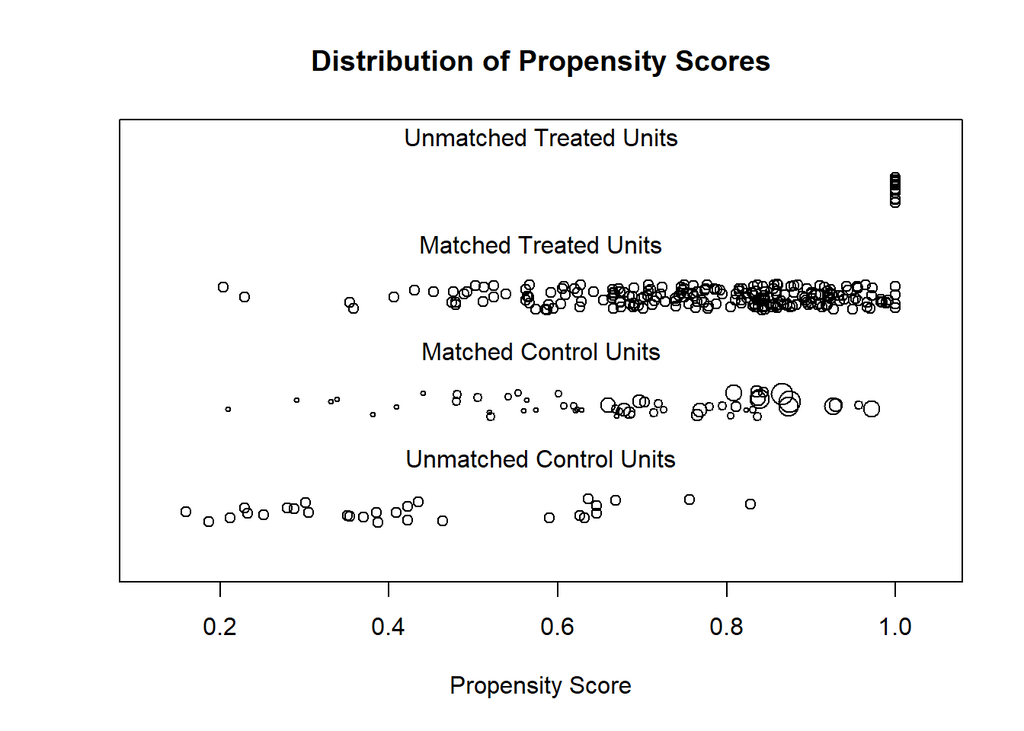

Figure 2: Matches chosen using nearest neighbor with replacement matching on propensity score. Operations with DTC sales = Treated, Non-Dtc sales = Control. Size of Matched Control units (unfilled circles) is proportional to the weight assigned. 15 Treatment units and 29 Control remain unmatched.

```r
plot(nnr_1, type = "jitter", interactive = FALSE)
```

```r
new.names <- c("distance" = "Propensity Score Difference",
                "NOAA_region_West Coast" = "Region: West Coast",
               "NOAA_region_Alaska" = "Region: Alaska",
               "NOAA_region_Gulf of Mexico" = "Region: Gulf of Mexico",
               "NOAA_region_Mid-Atlantic" = "Region: Mid-Atlantic",
               "NOAA_region_New England" = "Region: New England",
               "NOAA_region_South Atlantic" = "Region: South Atlantic",
               "NOAA_region_Hawaii" = "Region: Hawaii",
               "Family_owned" = "Family Owned (Y/N)",
               "MajorOccupation_Other" = "Other Primary Occupation",
               "Sex" = "Sex", "mkt_exp" = "Marketing Experience (Yrs)",
               "OMB_Race_American Indian or Alaska Native" = "Race: American Indian or Alaska Native",
               "OMB_Race_Asian" = "Race: Asian",
               "OMB_Race_Black or African American" = "Race: Black or African American",
               "OMB_Race_Multiracial" = "Race: Multiracial",
               "OMB_Race_NA" = "Race: NA",
               "OMB_Race_Native Hawaiian or Other Pacific Islander" = "Race: Native Hawaiian or Other Pacific Islander",
               "OMB_Race_White" = "Race: White",
               "medincome" = "County: Median Income",
               "num_employees" = "Number of Employees",
               "Live" = "Seafood: Live",
               "Fresh_chilled" = "Seafood: Fresh or Chilled",
               "Frozen" = "Seafood: Frozen",
               "Finfish" = "Seafood: Finfish",
               "Crustaceans" = "Seafood: Crustaceans",
               "Mollusks" = "Seafood: Mollusks",
               "RUCC_2023_9" = "County: RUCC 9",
               "RUCC_2023_8" = "County: RUCC 8",
               "RUCC_2023_7" = "County: RUCC 7",
               "RUCC_2023_6" = "County: RUCC 6",
               "RUCC_2023_5" = "County: RUCC 5",
               "RUCC_2023_4" = "County: RUCC 4",
               "RUCC_2023_3" = "County: RUCC 3",
               "RUCC_2023_2" = "County: RUCC 2",
               "RUCC_2023_1" = "County: RUCC 1",
               "medincome" = "County: Median Income",
               "seafood_jobs" = "State: Number of Seafood Jobs",
               "landing_dollars" = "State: Seafood Landings Value (USD)",
               "ag_retail_usd" = "Direct Ag: Retail Dollar Values",
               "ag_wholesale_ops" = "Direct Ag: Wholesale Operations",
               "fsa_usd" = "Direct Ag: Foodservice Dollar Values")
```

```r
fig_2 <- love.plot(nnr_1, abs = TRUE,
          stats = c("m"),
          stars = "raw",
          thresholds = .1,
          var.names = new.names,
          shapes = c("circle filled", "circle"),
          sample.names = c("Original", "Matched"),
          position = c(.75, .3),
          limits = c(0, 0.35)) +
  theme(legend.box.background = element_rect(),
        legend.box.margin = margin(1,1,1,1))

ggsave(plot = fig_2, here("plots", "Fig2.tif"), width = 183, height = 130, units = "mm", bg = "white")

matched_1 <- match_data(nnr_1) %>%
  mutate(NOAA_region = fct_drop(NOAA_region))
dtc_matched_data <- get_matches(nnr_1)
```

We use frequently tested covariates that have been identified as significantly influencing agricultural direct sales. The covariates used to develop balanced control and treatment groups include demographic characteristics of direct seafood business owners, charactistics of the business, and regional and county-level indicators of the seafood industry and the direct marketing economy. The table and figures above indicate we have common support and can proceed with analysing the matched data in an interval regression.

## 2.3 Interval Regression Modeling

We analyzed direct sales revenue outcomes using parametric interval regression (Therneau, 2024). This approach is well-suited for interval-censored data where the true dependent variable (actual direct sales revenue) is not directly observed, but instead falls within known brackets or intervals. We assume that the latent continuous income variable lies between the lower and upper bounds of income categories and follows a lognormal distribution. We implement a right-censored interval regression due to our last income bracket being $250,000 and over.

We tested three model specifications to evaluate:

- Model 1: Income regressed on DTC engagement (basic, binary model)
- Model 2: Income regressed on DTC engagement with region as a fixed effect (adjusted binary model)
- Model 3: Income regressed on Marketing Strategy (different combinations of marketing channels) with only DTC sales set as the intercept to compare against. Includes region as a fixed effect (full model)

Model predictions were exponentiated to obtain predicted median income in dollar terms for each strategy type, with 95% confidence intervals calculated from the model’s standard errors.

# 3 Results

## 3.1 Matched Sample Characteristics and Market Channel Use

From a total of N=595 valid survey responses, the usable sample with complete information on covariates of interest was 323. This sample size further reduced to N = 279 in our matched dataset, with 56 non-DTC businesses (Control) and 223 businesses engaging with DTC (Treatment).

```r
fig_3 <- upset(matched_1,
      name = 'Direct Seafood Marketing Channel Combinations',
      intersect = c("Consumer", "Retail", "Foodservice", "Institution", "SID"),
      base_annotations = list(
        'Intersection size' = intersection_size()
        + ylab('No. Direct Marketing\n Channel Combinations')
      ),
      set_sizes = upset_set_size(
        filter_intersections = TRUE)
            + geom_text(aes(label=after_stat(count)), hjust=1.1, stat='count')
      + expand_limits(y=254)
      + ylab('Marketing Channel Usage'))

ggsave(plot = fig_3, here("plots", "Fig3.tif"), width = 183, height = 80, units = "mm", bg = "white")
```

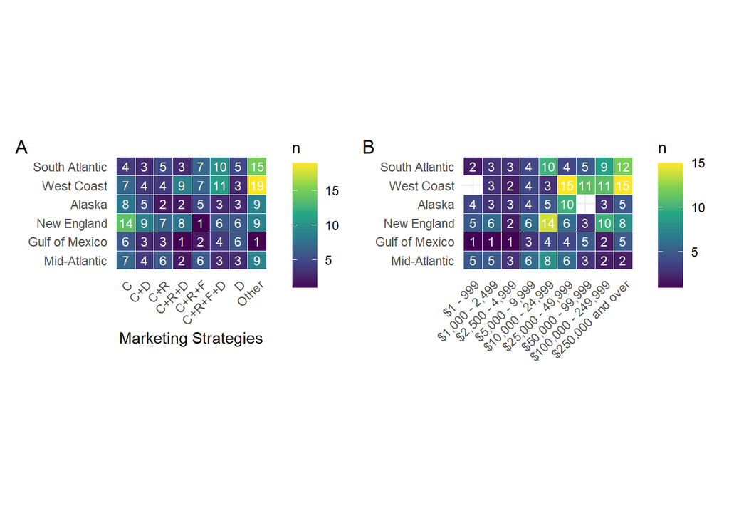

```r
f4_a <- matched_1 %>%
  count(strategy_type_grouped, NOAA_region) %>%
  ggplot(aes(y = NOAA_region, x = strategy_type_grouped, fill = n)) +
  geom_tile(color = "white") +
  geom_text(aes(label = n), color = "white", size = 3) +
  coord_fixed() + scale_fill_viridis_c(option = "D") +
  theme_minimal() +
  labs(y = NULL,
       x = "Marketing Strategies") +
  theme(axis.text.x = element_text(angle = 45, hjust = 1))

f4_b <- matched_1 %>%
  count(direct_income_clip, NOAA_region) %>%
  ggplot(aes(y = NOAA_region, x = direct_income_clip, fill = n)) +
  geom_tile(color = "white") +
  geom_text(aes(label = n), color = "white", size = 3) +
  coord_fixed() + scale_fill_viridis_c(option = "D") +
  theme_minimal() +
  labs(y = NULL, x = NULL) +
  theme(axis.text.x = element_text(angle = 45, hjust = 1))

fig_4 <- f4_a + f4_b + plot_annotation(tag_levels = 'A')

fig_4
```

```r
ggsave(plot = fig_4, here("plots", "Fig4.tif"), width = 183, height = 80, units = "mm", bg = "white")
```

## 3.2 Interval Regression Model Results

```r
# Create Surv object (type = interval2 handles Inf for right-censored)
matched_1$surv_income <- with(matched_1, Surv(income_lower, income_upper, type = "interval2"))

mod_1 <- survreg(
  surv_income ~ Consumer,
  data = matched_1,
  dist = "lognormal")

mod_2 <- survreg(
  surv_income ~ Consumer + NOAA_region,
  data = matched_1,
  dist = "lognormal")

mod_3 <- survreg(
  surv_income ~ strategy_type_grouped + NOAA_region,
  data = matched_1,
  dist = "lognormal")

summary(mod_1)
```

```
Call:
survreg(formula = surv_income ~ Consumer, data = matched_1, dist = "lognormal")
              Value Std. Error     z       p
(Intercept) 11.3796     0.2991 38.04 < 2e-16
Consumer    -1.2699     0.3324 -3.82 0.00013
Log(scale)   0.7545     0.0517 14.60 < 2e-16

Scale= 2.13

Log Normal distribution
Loglik(model)= -588.1   Loglik(intercept only)= -595.3
    Chisq= 14.51 on 1 degrees of freedom, p= 0.00014
Number of Newton-Raphson Iterations: 3
n= 279
```

```r
summary(mod_2)
```

```
Call:
survreg(formula = surv_income ~ Consumer + NOAA_region, data = matched_1,
    dist = "lognormal")
                            Value Std. Error     z       p
(Intercept)               10.2142     0.4228 24.16 < 2e-16
Consumer                  -1.1842     0.3169 -3.74 0.00019
NOAA_regionGulf of Mexico  1.2989     0.5221  2.49 0.01286
NOAA_regionNew England     0.7577     0.4208  1.80 0.07175
NOAA_regionAlaska          0.5921     0.4699  1.26 0.20762
NOAA_regionWest Coast      2.0178     0.4179  4.83 1.4e-06
NOAA_regionSouth Atlantic  1.4339     0.4363  3.29 0.00101
Log(scale)                 0.6982     0.0516 13.52 < 2e-16

Scale= 2.01

Log Normal distribution
Loglik(model)= -574   Loglik(intercept only)= -595.3
    Chisq= 42.58 on 6 degrees of freedom, p= 1.4e-07
Number of Newton-Raphson Iterations: 4
n= 279
```

```r
summary(mod_3)
```

```
Call:
survreg(formula = surv_income ~ strategy_type_grouped + NOAA_region,
    data = matched_1, dist = "lognormal")
                              Value Std. Error     z       p
(Intercept)                  7.2854     0.3883 18.76 < 2e-16
strategy_type_groupedC+D     1.8095     0.4388  4.12 3.7e-05
strategy_type_groupedC+R     1.2187     0.4473  2.72  0.0064
strategy_type_groupedC+R+D   1.9000     0.4583  4.15 3.4e-05
strategy_type_groupedC+R+F   2.5420     0.4490  5.66 1.5e-08
strategy_type_groupedC+R+F+D 3.0020     0.4195  7.16 8.3e-13
strategy_type_groupedD       2.9366     0.4632  6.34 2.3e-10
strategy_type_groupedOther   2.7239     0.3706  7.35 2.0e-13
NOAA_regionGulf of Mexico    1.4978     0.4704  3.18  0.0015
NOAA_regionNew England       1.0420     0.3800  2.74  0.0061
NOAA_regionAlaska            0.5794     0.4195  1.38  0.1672
NOAA_regionWest Coast        1.7568     0.3759  4.67 3.0e-06
NOAA_regionSouth Atlantic    1.1133     0.3896  2.86  0.0043
Log(scale)                   0.5745     0.0515 11.14 < 2e-16

Scale= 1.78

Log Normal distribution
Loglik(model)= -543   Loglik(intercept only)= -595.3
    Chisq= 104.58 on 12 degrees of freedom, p= 7e-17
Number of Newton-Raphson Iterations: 4
n= 279
```

```r
t1 <- mod_1 |> tbl_regression(exponentiate = TRUE,
                              label = list(Consumer ~ "DTC")) |>
  add_significance_stars(
    pattern = "{estimate} ({conf.low}, {conf.high}){stars}",
    hide_ci = TRUE, hide_se = TRUE
  ) |>
  modify_header(estimate = "**Beta (95% CI)**") |>
  modify_abbreviation("CI = Confidence Interval") |> add_glance_table(include = c(AIC))

t2 <- mod_2 |> tbl_regression(exponentiate = TRUE,
                              label = list(Consumer ~ "DTC")) |>
  add_significance_stars(
    pattern = "{estimate} ({conf.low}, {conf.high}){stars}",
    hide_ci = TRUE, hide_se = TRUE
  ) |>
  modify_header(estimate = "**Beta (95% CI)**") |>
  modify_abbreviation("CI = Confidence Interval") |> add_glance_table(include = c(AIC))

t3 <- mod_3 |> tbl_regression(exponentiate = TRUE) |>
  add_significance_stars(
    pattern = "{estimate} ({conf.low}, {conf.high}){stars}",
    hide_ci = TRUE, hide_se = TRUE
  ) |>
  modify_header(estimate = "**Beta (95% CI)**") |>
  modify_abbreviation("CI = Confidence Interval") |> add_glance_table(include = c(AIC))

t_merge <- tbl_merge(
  tbls = list(t1,t2,t3),
  tab_spanner = c("**Model 1:\nDTC vs non-DTC**", "**Model 2:\nRegional Effects**", "**Model 3:\nMarketing Strategies**")) |>
  as_gt()

t_merge
```

Interval regression model estimates predicting direct seafood sales revenue (lognormal regression, n = 279)

| **Characteristic** | **Model 1: DTC vs non-DTC** **Beta (95% CI)**<sup>1</sup> | **Model 2: Regional Effects** **Beta (95% CI)**<sup>1</sup> | **Model 3: Marketing Strategies** **Beta (95% CI)**<sup>1</sup> |
| --- | --- | --- | --- |
| DTC | -1.27 (-1.92, -0.62)*** | -1.18 (-1.81, -0.56)*** |  |
| AIC | 1,182 | 1,164 | 1,114 |
| NOAA_region |  |  |  |
| Mid-Atlantic |  | — | — |
| Gulf of Mexico |  | 1.30 (0.28, 2.32)* | 1.50 (0.58, 2.42)** |
| New England |  | 0.76 (-0.07, 1.58) | 1.04 (0.30, 1.79)** |
| Alaska |  | 0.59 (-0.33, 1.51) | 0.58 (-0.24, 1.40) |
| West Coast |  | 2.02 (1.20, 2.84)*** | 1.76 (1.02, 2.49)*** |
| South Atlantic |  | 1.43 (0.58, 2.29)** | 1.11 (0.35, 1.88)** |
| strategy_type_grouped |  |  |  |
| C |  |  | — |
| C+D |  |  | 1.81 (0.95, 2.67)*** |
| C+R |  |  | 1.22 (0.34, 2.10)** |
| C+R+D |  |  | 1.90 (1.00, 2.80)*** |
| C+R+F |  |  | 2.54 (1.66, 3.42)*** |
| C+R+F+D |  |  | 3.00 (2.18, 3.82)*** |
| D |  |  | 2.94 (2.03, 3.84)*** |
| Other |  |  | 2.72 (2.00, 3.45)*** |

Abbreviation: CI = Confidence Interval  
<sup>1</sup> *p<0.05; **p<0.01; ***p<0.001

### 3.2.1 Model Predictions

```r
valid_regions <- levels(matched_1$NOAA_region)

newdata <- expand.grid(
  strategy_type_grouped = levels(as.factor(matched_1$strategy_type_grouped)),
  NOAA_region = valid_regions)

pred <- predict(mod_3, newdata = newdata, se.fit = TRUE, type = "link")
log_scale <- mod_3$scale

# Convert from log-scale to income scale (median of lognormal)
newdata <- newdata %>%
  mutate(pred_link = pred$fit,
         se_link = pred$se.fit,
         pred_median = exp(pred_link),
         ci_lower = exp(pred_link - 1.96 * se_link),
         ci_upper = exp(pred_link + 1.96 * se_link)
  )

pred_df <- newdata %>%
  mutate(strategy_label = recode(strategy_type_grouped,
  "C" = "Consumer Only (46)",
  "C+D" = "Consumer & SID (28)",
  "C+R" = "Consumer & Retail (27)",
  "C+R+D" = "Consumer & Retail & SID (25)",
  "C+R+F" = "Consumer & Retail & \nFoodservice (28)",
  "C+R+F+D" = "Consumer & Retail & \nFoodservice & SID (37)",
  "D" = "SID Only (26)",
  "Other" = "Other Combinations (62)"),
  strategy_label_short = recode(strategy_type_grouped,
  "C" = "C only (46)",
  "C+D" = "C & SID (28)",
  "C+R" = "C & R (27)",
  "C+R+D" = "C & R & SID (25)",
  "C+R+F" = "C & R & F (28)",
  "C+R+F+D" = "C & R & F & SID (37)",
  "D" = "SID Only (26)",
  "Other" = "Other Combos (62)"),
  region_label = recode(NOAA_region,
                        "Alaska" = "Alaska (37)",
                        "West Coast" = "West Coast (64)",
                        "Gulf of Mexico" = "Gulf of Mexico (26)",
                        "Mid-Atlantic" = "Mid-Atlantic (40)",
                        "New England" = "New England (60)",
                        "South Atlantic" = "South Atlantic (52)"))

overall_df <- pred_df %>%
  group_by(strategy_type_grouped, strategy_label, strategy_label_short) %>%
  summarise(
    pred_median = mean(pred_median, na.rm = TRUE),
    ci_lower = mean(ci_lower, na.rm = TRUE),
    ci_upper = mean(ci_upper, na.rm = TRUE),
    .groups = "drop"
  ) %>%
  mutate(region_label = "All Regions (n = 279)")

pred_tab <- overall_df %>% select(-strategy_type_grouped, -strategy_label, -region_label)
pred_tab
```

```
# A tibble: 8 × 4
  strategy_label_short pred_median ci_lower ci_upper
  <fct>                      <dbl>    <dbl>    <dbl>
1 C only (46)                4603.    2190.    9717.
2 C & SID (28)              28109.   12033.   65935.
3 C & R (27)                15570.    6584.   36970.
4 C & R & SID (25)          30772.   12845.   74341.
5 C & R & F (28)            58477.   24921.  138040.
6 C & R & F & SID (37)      92629.   42265.  204291.
7 SID Only (26)             86763.   35766.  210747.
8 Other Combos (62)         70141.   35230.  141353.
```

```r
pred_df_combined <- bind_rows(pred_df, overall_df) %>%
  mutate(region_label = fct_relevel(region_label, "All Regions (n = 279)"))

fig_5 <- ggplot(pred_df_combined, aes(x = reorder(strategy_label_short, pred_median), y = pred_median)) +
  geom_point(size = 3) +
  geom_errorbar(aes(ymin = ci_lower, ymax = ci_upper), width = 0.2) +
  scale_y_continuous(labels = dollar_format()) +
  facet_wrap(.~region_label, ncol = 2) +
  labs(x = "Marketing Strategy",
    y = "Predicted Median Income (USD)"
  ) +
  theme_minimal(base_size = 12) +
  coord_flip() +
  theme(panel.spacing = unit(0.5, "lines"),
        strip.text = element_text(size = 11))

ggsave(plot = fig_5, here("plots", "Fig5.tif"), width = 183, height = 160, units = "mm", bg = "white")
```